# P5

## P5: Convolutioneel Neuraal Netwerk

In dit notebook bouwen we een neuraal netwerk met de hulp van tensorflow en keras. Hier onder zie je de belangrijke imports. Je ziet de import ssl, had ik nodig omdat ik anders een error kreeg bij het laden van de dataset. Deze import verhielp dat probleem.

```python
import tensorflow as tf
import matplotlib.pyplot as plt
from tensorflow.keras import layers, models
from keras.layers import Dropout, BatchNormalization
from tensorflow.keras.datasets import cifar10

import ssl
ssl._create_default_https_context = ssl._create_unverified_context
```

Nu de data ingeladen is kunnen we het splitsen in train en test data. Ook normaliseren we de waardes van de test en train images zodat die tussen de 0 en 1 komen.

```python
#splitst de data in test en train sets
(train_images, train_labels), (test_images, test_labels) = cifar10.load_data()

#Normaliseert de test en train sets
train_images, test_images = train_images / 255.0, test_images / 255.0
```

Nu de verschillende sets zijn aangemaakt kunnen we ook kijken hoe de data er uit ziet. De afbeeldingen worden met hun label hieronder geplot.

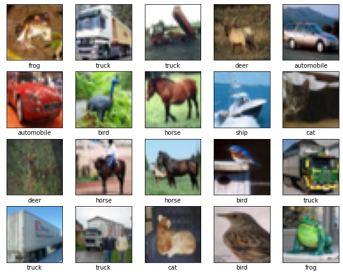

```python
class_names = ['airplane', 'automobile', 'bird', 'cat', 'deer',
               'dog', 'frog', 'horse', 'ship', 'truck']

# Plot de eerste 20 afbeeldingen
plt.figure(figsize=(10,10))
for i in range(20):
    plt.subplot(5,5,i+1)
    plt.xticks([])
    plt.yticks([])
    plt.imshow(train_images[i])
    plt.xlabel(class_names[train_labels[i][0]])
plt.show()
```

### Baseline Model

Het baseline model is erg simpel. Het model gokt altijd dat het een airplane is en dan zou hij het in 10% van de gevallen goed moeten hebben.

```python
#baseline model:
goed = 0
fout = 0
gok = 'airplane'
for i in range(len(train_images)):
    if class_names[train_labels[i][0]] == gok:
        goed += 1
    else:
        fout+=1

print('Het aantal keer dat hij goed gokt is ' + str(goed) + ', Het aantal keer dat hij goed gokt is ' + str(fout))
```

```
Het aantal keer dat hij goed gokt is 5000, Het aantal keer dat hij goed gokt is 45000
```

### Convolutioneel Neuraal Netwerk

Nu we het baseline model hebben weten we wat we moeten overtreffen en kunnen we een echt netwerk gaan bouwen. Ik maak gebruik van verschillende technieken. Batch normalization voert een transformatie uit waardoor de gemiddelde outputs dicht bij 0 of 1 blijven. Ook maak ik gebruik van de Dropout functie. De dropout functie zorgt ervoor dat er een bepaald procent van de neuronen niet mee doet tijdens die itteratie en voorkomt dus dat het netwerk afhankelijk wordt van een specefieke neuron. Ik heb het percentage op 20% gezet. MaxPooling vermindert de parameters door de hoogste waarde te kiezen dit zorgt er voor dat het model sneller is. In elke laag gebruik ik de relu als activatie functie. Die was het meest voorkomend en het meest gebruikt.

```python
model = models.Sequential()
```

```python
model.add(layers.Conv2D(32, (3, 3), padding ='same', activation='relu', input_shape=(32, 32, 3)))
model.add(Dropout(0.2))
model.add(BatchNormalization())


model.add(layers.Conv2D(64, (3, 3),padding ='same', activation='relu'))
model.add(layers.MaxPooling2D((2, 2)))
model.add(Dropout(0.2))
model.add(BatchNormalization())


model.add(layers.Conv2D(128, (3, 3),padding ='same', activation='relu'))
model.add(layers.MaxPooling2D((2, 2)))
model.add(Dropout(0.2))
model.add(BatchNormalization())
```

```python
model.summary()
```

```
Model: "sequential_6"
_________________________________________________________________
 Layer (type)                Output Shape              Param #
=================================================================
 conv2d_20 (Conv2D)          (None, 32, 32, 32)        896

 dropout_32 (Dropout)        (None, 32, 32, 32)        0

 batch_normalization_30 (Bat  (None, 32, 32, 32)       128
 chNormalization)

 conv2d_21 (Conv2D)          (None, 32, 32, 64)        18496

 max_pooling2d_13 (MaxPoolin  (None, 16, 16, 64)       0
 g2D)

 dropout_33 (Dropout)        (None, 16, 16, 64)        0

 batch_normalization_31 (Bat  (None, 16, 16, 64)       256
 chNormalization)

 conv2d_22 (Conv2D)          (None, 16, 16, 128)       73856

 max_pooling2d_14 (MaxPoolin  (None, 8, 8, 128)        0
 g2D)

 dropout_34 (Dropout)        (None, 8, 8, 128)         0

 batch_normalization_32 (Bat  (None, 8, 8, 128)        512
 chNormalization)

=================================================================
Total params: 94,144
Trainable params: 93,696
Non-trainable params: 448
_________________________________________________________________
```

De output kan geen 3x3 matrix zijn dus gebruik ik de functie Flatten om er een 1 matrix van te maken. Ook zie je dat we in de laatste laag de softmax functie gebruiken. Dit gebeurt vaak bij classificatie modellen het output namelijk een voorspelling, een kans dat het die klasse is.

```python
# De output kan geen 3x3 matrix zijn dus gebruiken we de functie flatten om er 1 matrix van te maken.
model.add(layers.Flatten())
model.add(Dropout(0.2))

model.add(layers.Dense(256, activation='relu'))
model.add(Dropout(0.2))
model.add(BatchNormalization())

# Dense zetten we op 10 omdat we 10 verschillende outputs (classes) willen
model.add(layers.Dense(10, activation='softmax'))
```

Nu het model compleet is kunnen we het gaat compile en fitten. Als optimizer heb ik adam gekozen want die wordt het meest gebruikt en is in de meeste gevallen het best. Het aantal epochs staat op 15.

```python
model.compile(optimizer='adam',
              loss=tf.keras.losses.SparseCategoricalCrossentropy(from_logits=True),
              metrics=['accuracy'])

history = model.fit(train_images, train_labels, epochs=15,
                    validation_data=(test_images, test_labels))
```

```
313/313 - 9s - loss: 0.6422 - accuracy: 0.8009 - 9s/epoch - 30ms/step
```

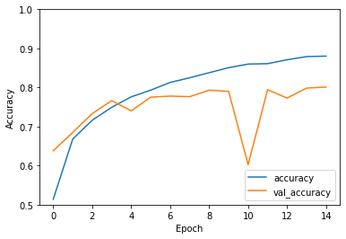

```python
plt.plot(history.history['accuracy'], label='accuracy')
plt.plot(history.history['val_accuracy'], label = 'val_accuracy')
plt.xlabel('Epoch')
plt.ylabel('Accuracy')
plt.ylim([0.5, 1])
plt.legend(loc='lower right')

test_loss, test_acc = model.evaluate(test_images,  test_labels, verbose=2)
```

```python
# Score Test
score = model.evaluate(test_images,  test_labels)
print('Test score:', score[0])
print('Test accuracy:', score[1])
```

```
Test score: 0.6421534419059753
Test accuracy: 0.8008999824523926
```

Ik zie dat het model vanaf epoch 11 de val_accuracy minder wordt of het zelfde blijft terwijl de accuracy omhoog gaat. Dit is een teken van overfitten. Ook zie ik dat de accuracy vanaf epoch 10 maar minimaal toe neemt. Ook zie je bij epoch dat de val_accuracy voor een epoch heel erg afnam. De accuracy op de test set is 80% en daar ben ik best tevreden mee. Ik maak het zelfde model aan maar deze keer run ik hem met 10 epochs om te kijken of we in minder train tijd alsnog tot een acceptabele score kunnen krijgen en overfitten kunnen voorkomen.

```python
model2 = models.Sequential()
```

```python
model2.add(layers.Conv2D(32, (3, 3), padding ='same', activation='relu', input_shape=(32, 32, 3)))
model2.add(Dropout(0.2))
model2.add(BatchNormalization())

model2.add(layers.Conv2D(64, (3, 3),padding ='same', activation='relu'))
model2.add(layers.MaxPooling2D((2, 2)))
model2.add(Dropout(0.2))
model2.add(BatchNormalization())

model2.add(layers.Conv2D(128, (3, 3),padding ='same', activation='relu'))
model2.add(layers.MaxPooling2D((2, 2)))
model2.add(Dropout(0.2))
model2.add(BatchNormalization())
```

```python
model2.add(layers.Flatten())
model2.add(Dropout(0.2))

model2.add(layers.Dense(256, activation='relu'))
model2.add(Dropout(0.2))
model2.add(BatchNormalization())

model2.add(layers.Dense(10, activation='softmax'))
```

```python
model2.compile(optimizer='adam',
              loss=tf.keras.losses.SparseCategoricalCrossentropy(from_logits=True),
              metrics=['accuracy'])

history = model2.fit(train_images, train_labels, epochs=10,
                    validation_data=(test_images, test_labels))
```

```
313/313 - 8s - loss: 0.6277 - accuracy: 0.7920 - 8s/epoch - 25ms/step
```

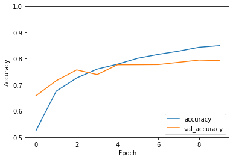

```python
plt.plot(history.history['accuracy'], label='accuracy')
plt.plot(history.history['val_accuracy'], label = 'val_accuracy')
plt.xlabel('Epoch')
plt.ylabel('Accuracy')
plt.ylim([0.5, 1])
plt.legend(loc='lower right')

test_loss, test_acc = model2.evaluate(test_images,  test_labels, verbose=2)
```

```python
# Score Test
score = model2.evaluate(test_images,  test_labels)
print('Test score:', score[0])
print('Test accuracy:', score[1])
```

```
Test score: 0.6277403235435486
Test accuracy: 0.7919999957084656
```

Dit model met 10 epochs scoort 79% procent. Je ziet dat de val_accuracy bij epoch 10 iets afneemt dus we komen tegen overfitting aan.

### Conclusie

Het eerste model was ingesteld op 15 epochs en haalde een score van 80%. Het tweede model was ingesteld op 10 epochs en behaalde een score van 79%. Dat is een afname van 1% maar het duurde 33% minder tijd om te trainen dus ik vind dit een succes.